# Pincipal Component Analysis

In this post, I will be discussing Principal Component Analysis (PCA) and how it can be used in datasets to understand variation with many different variables. Many real-world datasets are often in high dimensions. In otherwords, they contain so many variables that it is difficult to distinguish a trend.

PCA is a type of dimensional reduction method that can assist us by identifying which variables contribute to the variation within the data. It is similar to fitting a best fit line onto a 2D graph, but in this case there may be more than three-dimensions of data. It is formulated in the language of linear algebra and is an often used technique in data science and bioinformatics.

```r
library(ggplot2)
library(cowplot) # required to arrange multiple plots in a grid
library(dplyr)
```

```r
head(iris)
```

|  | Sepal.Length | Sepal.Width | Petal.Length | Petal.Width | Species |
| --- | --- | --- | --- | --- | --- |
| 1 | 5.1 | 3.5 | 1.4 | 0.2 | setosa |
| 2 | 4.9 | 3.0 | 1.4 | 0.2 | setosa |
| 3 | 4.7 | 3.2 | 1.3 | 0.2 | setosa |
| 4 | 4.6 | 3.1 | 1.5 | 0.2 | setosa |
| 5 | 5.0 | 3.6 | 1.4 | 0.2 | setosa |
| 6 | 5.4 | 3.9 | 1.7 | 0.4 | setosa |

Let us try to observe some patterns with different combinations of variables.

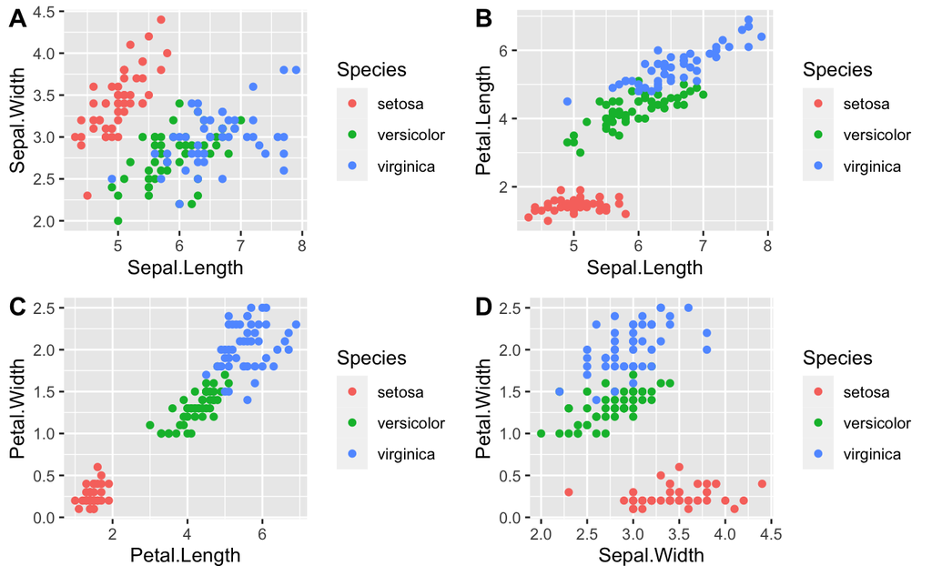

```r
p1 <- ggplot(iris, aes(x=Sepal.Length, y=Sepal.Width, color=Species)) + geom_point()
p2 <- ggplot(iris, aes(x=Sepal.Length, y=Petal.Length, color=Species)) + geom_point()
p3 <- ggplot(iris, aes(x=Petal.Length, y=Petal.Width, color=Species)) + geom_point()
p4 <- ggplot(iris, aes(x=Sepal.Width, y=Petal.Width, color=Species)) + geom_point()
plot_grid(p1, p2, p3, p4, labels = "AUTO")
```

As you can see from the graphs, petal length, petal width, and perhaps sepal length contribute the most to the differences between the three species.

Let’s try using PCA as a better method for detecting such patterns. First, we will only include numerical data. We will pass our dataset (excluding the Species column) into the function `prcomp`. `center` and `scale` will be set to true to scale the data to 0 mean and unit variance.

```r
iris.pca <- prcomp(iris[,1:4], center = TRUE, scale. = TRUE)
summary(iris.pca)
```

```
Importance of components:
                          PC1    PC2     PC3     PC4
Standard deviation     1.7084 0.9560 0.38309 0.14393
Proportion of Variance 0.7296 0.2285 0.03669 0.00518
Cumulative Proportion  0.7296 0.9581 0.99482 1.00000
```

The main results are that Principal Components 1 and 2 explains the majority of the variance within the dataset. These values are derived from the eigenvectors and eigenvalues from the covariance matrix.

To better understand, you will need a basic understanding of eigenvectors and eigenvalues. To simply put, an eigenvector is a vector whose direction remains unchanged after a linear transformation. In that regard, an eigenvector provides direction or orientation of the data, like 90 or 45 degrees. The change after a linear transformation is described as the eigenvalue. In other words, the variance or spread of the data is explained by the eigenvalue. In addition, an *n*-th dimensional matrix will have the same *n* eigenvectors/eigenvalues. Therefore, each principal component is an eigenvector and PC1 has the highest eigenvalue (highest variance).

We can observe the results of the linear transformation with `iris.pca$x`.

```r
head(iris.pca$x)
```

```
           PC1        PC2         PC3          PC4
[1,] -2.257141 -0.4784238  0.12727962  0.024087508
[2,] -2.074013  0.6718827  0.23382552  0.102662845
[3,] -2.356335  0.3407664 -0.04405390  0.028282305
[4,] -2.291707  0.5953999 -0.09098530 -0.065735340
[5,] -2.381863 -0.6446757 -0.01568565 -0.035802870
[6,] -2.068701 -1.4842053 -0.02687825  0.006586116
```

Let’s add back in the species data.

```r
pca_data <- data.frame(iris.pca$x, Species=iris$Species)
head(pca_data)
```

|  | PC1 | PC2 | PC3 | PC4 | Species |
| --- | --- | --- | --- | --- | --- |
| 1 | -2.257141 | -0.4784238 | 0.12727962 | 0.024087508 | setosa |
| 2 | -2.074013 | 0.6718827 | 0.23382552 | 0.102662845 | setosa |
| 3 | -2.356335 | 0.3407664 | -0.04405390 | 0.028282305 | setosa |
| 4 | -2.291707 | 0.5953999 | -0.09098530 | -0.065735340 | setosa |
| 5 | -2.381863 | -0.6446757 | -0.01568565 | -0.035802870 | setosa |
| 6 | -2.068701 | -1.4842053 | -0.02687825 | 0.006586116 | setosa |

Next, we will plot the first two principal components as these would explain the highest variation within the data.

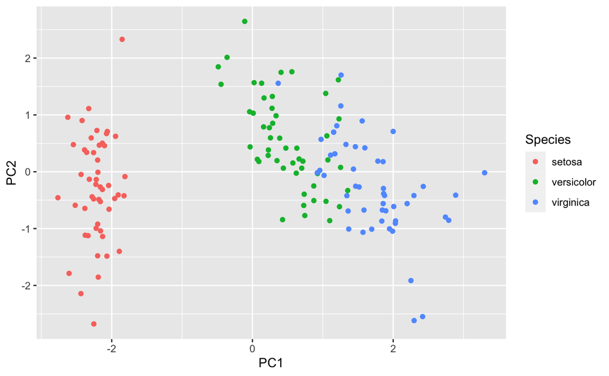

```r
ggplot(pca_data, aes(x=PC1, y=PC2, color=Species)) + geom_point()
```

We can observe that setosa separates further from versicolor and virginica. To understand which variables contribute to this variation in the data, we will call `iris.pca$rotation`.

```r
iris.pca$rotation
```

```
                    PC1         PC2        PC3        PC4
Sepal.Length  0.5210659 -0.37741762  0.7195664  0.2612863
Sepal.Width  -0.2693474 -0.92329566 -0.2443818 -0.1235096
Petal.Length  0.5804131 -0.02449161 -0.1421264 -0.8014492
Petal.Width   0.5648565 -0.06694199 -0.6342727  0.5235971
```

Here we can see that `Sepal.Length`, `Petal.Length`, and `Petal.Width` contributes quite a bit to PC1 compared to `Sepal.Width`. However, Sepal.Width contributes greatly to PC2.

Therefore, based on the above graph, we can infer that variance in the x-axis is due to `Sepal.Length`, `Petal.Length`, and `Petal.Width` and variance in the y-axis is due to `Sepal.Width`. Running the following code will show this concept as vectors.

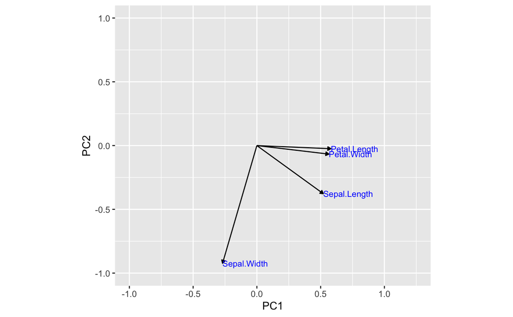

```r
# capture the rotation matrix in a data frame
rotation_data <- data.frame(iris.pca$rotation, variable=row.names(iris.pca$rotation))
# define a pleasing arrow style
arrow_style <- arrow(length = unit(0.05, "inches"),
                     type = "closed")
# now plot, using geom_segment() for arrows and geom_text for labels
ggplot(rotation_data) +
  geom_segment(aes(xend=PC1, yend=PC2), x=0, y=0, arrow=arrow_style) +
  geom_text(aes(x=PC1, y=PC2, label=variable), hjust=0, size=3, color='blue') +
  xlim(-1.,1.25) +
  ylim(-1.,1.) +
  coord_fixed() # fix aspect ratio to 1:1
```

As you can see, before performing a PCA, we used four graphs to observe the conclusion that petal length, petal width, and sepal length contributed the most to the variance in species. With PCA, we could easily observe this with the PCA plot of PC1 vs PC2. In addition, we used a simple dataset to illustrate this. Many real-world datasets consists of much higher dimensions.

Sources and additional information:

https://www.datacamp.com/community/tutorials/pca-analysis-r

https://wilkelab.org/classes/SDS348/2016_spring/worksheets/class9.html